# Description

## Background and Context

Businesses like banks that provide service have to worry about the problem of 'Churn' i.e. customers leaving and joining another service provider. It is important to understand which aspects of the service influence a customer's decision in this regard. Management can concentrate efforts on the improvement of service, keeping in mind these priorities.

## Objective

Given a Bank customer, build a neural network-based classifier that can determine whether they will leave or not in the next 6 months.

## Data Description

The case study is from an open-source dataset from Kaggle. The dataset contains 10,000 sample points with 14 distinct features such as CustomerId, CreditScore, Geography, Gender, Age, Tenure, Balance, etc.

## Data Dictionary

- CustomerId: Unique ID which is assigned to each customer
- Surname: Last name of the customer
- CreditScore: It defines the credit history of the customer.
- Geography: A customer’s location
- Gender: It defines the Gender of the customer
- Age: Age of the customer
- Tenure: Number of years for which the customer has been with the bank
- NumOfProducts: It refers to the number of products that a customer has purchased through the bank.
- Balance: Account balance
- HasCrCard: It is a categorical variable that decides whether the customer has a credit card or not.
- EstimatedSalary: Estimated salary
- isActiveMember: It is a categorical variable that decides whether the customer is an active member

### Importing necessary libraries

```python
# This will help in making the Python code more structured automatically (good coding practice)
%load_ext nb_black

import warnings
warnings.filterwarnings("ignore")

# Libraries to help with reading and manipulating data
import numpy as np
import pandas as pd

# Libraries to help with data visualization
import matplotlib.pyplot as plt
import seaborn as sns

%matplotlib inline

sns.set_theme()

# Removes the limit for the number of displayed columns
pd.set_option("display.max_columns", None)
# Sets the limit for the number of displayed rows
pd.set_option("display.max_rows", 200)

# Libraries for feature engineering.
from sklearn.preprocessing import StandardScaler, MinMaxScaler, OneHotEncoder
# Libraries to split dataset into train and test.
from sklearn.model_selection import train_test_split
# Libraries to built pipeline and processor.
from sklearn.pipeline import Pipeline
from sklearn.compose import ColumnTransformer

# Libraries to get diferent metric scores
from sklearn import metrics
from sklearn.metrics import (
    accuracy_score,
    recall_score,
    precision_score,
    f1_score,
    roc_auc_score,
    roc_curve,
    confusion_matrix,
    precision_recall_curve,
)

# Libraries to perform ML.
from xgboost import XGBClassifier
from sklearn.ensemble import RandomForestClassifier
from sklearn.neighbors import KNeighborsClassifier
from sklearn import tree

# Import tensor and keras library
import tensorflow as tf
from tensorflow import keras
from tensorflow.keras import Sequential
from tensorflow.keras.layers import Dense, Dropout
```

```python
# check the version of the tensor flow.

tf.__version__
```

```
'2.6.0'
```

## Load and review data

Load data set from "bank" csv file and review both structure and relevance of the data.

```python
# Load data from the CSV file.
data = pd.read_csv("bank.csv")

# creating a copy of the data so that original data remains unchanged
custData = data.copy()
custData.head()
```

|  | RowNumber | CustomerId | Surname | CreditScore | Geography | Gender | Age | Tenure | Balance | NumOfProducts | HasCrCard | IsActiveMember | EstimatedSalary | Exited |
| --- | --- | --- | --- | --- | --- | --- | --- | --- | --- | --- | --- | --- | --- | --- |
| 0 | 1 | 15634602 | Hargrave | 619 | France | Female | 42 | 2 | 0.00 | 1 | 1 | 1 | 101348.88 | 1 |
| 1 | 2 | 15647311 | Hill | 608 | Spain | Female | 41 | 1 | 83807.86 | 1 | 0 | 1 | 112542.58 | 0 |
| 2 | 3 | 15619304 | Onio | 502 | France | Female | 42 | 8 | 159660.80 | 3 | 1 | 0 | 113931.57 | 1 |
| 3 | 4 | 15701354 | Boni | 699 | France | Female | 39 | 1 | 0.00 | 2 | 0 | 0 | 93826.63 | 0 |
| 4 | 5 | 15737888 | Mitchell | 850 | Spain | Female | 43 | 2 | 125510.82 | 1 | 1 | 1 | 79084.10 | 0 |

### List of column data types in the dataset.

```python
# check the summary of the custDataAttr data frame.

custData.info()
```

```
<class 'pandas.core.frame.DataFrame'>
RangeIndex: 10000 entries, 0 to 9999
Data columns (total 14 columns):
 #   Column           Non-Null Count  Dtype
---  ------           --------------  -----
 0   RowNumber        10000 non-null  int64
 1   CustomerId       10000 non-null  int64
 2   Surname          10000 non-null  object
 3   CreditScore      10000 non-null  int64
 4   Geography        10000 non-null  object
 5   Gender           10000 non-null  object
 6   Age              10000 non-null  int64
 7   Tenure           10000 non-null  int64
 8   Balance          10000 non-null  float64
 9   NumOfProducts    10000 non-null  int64
 10  HasCrCard        10000 non-null  int64
 11  IsActiveMember   10000 non-null  int64
 12  EstimatedSalary  10000 non-null  float64
 13  Exited           10000 non-null  int64
dtypes: float64(2), int64(9), object(3)
memory usage: 1.1+ MB
```

**Observations**

- There are no null values.
- Surname, Geography and Gender columns has string values.

### Feature Elimination

Eliminating following unique features (features that cannot be used for prediction) in the data set as they are not useful for classification.

- RowNumber
- CustomerId
- Surname

```python
# Load only customer attributes relevent to neural network model.
# Discarding RowNumber, CustomerId and Surname

custDataAttr = custData.iloc[:, 3:]
custDataAttr.head()
```

|  | CreditScore | Geography | Gender | Age | Tenure | Balance | NumOfProducts | HasCrCard | IsActiveMember | EstimatedSalary | Exited |
| --- | --- | --- | --- | --- | --- | --- | --- | --- | --- | --- | --- |
| 0 | 619 | France | Female | 42 | 2 | 0.00 | 1 | 1 | 1 | 101348.88 | 1 |
| 1 | 608 | Spain | Female | 41 | 1 | 83807.86 | 1 | 0 | 1 | 112542.58 | 0 |
| 2 | 502 | France | Female | 42 | 8 | 159660.80 | 3 | 1 | 0 | 113931.57 | 1 |
| 3 | 699 | France | Female | 39 | 1 | 0.00 | 2 | 0 | 0 | 93826.63 | 0 |
| 4 | 850 | Spain | Female | 43 | 2 | 125510.82 | 1 | 1 | 1 | 79084.10 | 0 |

### Duplicate rows treatment

Identify and delete duplicate rows.

```python
# Check if there are any duplicated rows using duplicated method.

custDataAttr.duplicated().sum()
```

```
0
```

**Observations**

- There are no duplicate values.

### Missing row treatment

Identify missing rows and impute, if needed.

```python
""" Function to check missing values count and its percentage"""


def missing_check(df):
    total = (
        df.isnull().sum().sort_values(ascending=False)
    )  # total number of null values
    percent = (df.isnull().sum() / df.isnull().count()).sort_values(
        ascending=False
    )  # percentage of values that are null
    missing_data = pd.concat(
        [total, percent], axis=1, keys=["Total", "Percent"]
    )  # putting the above two together
    return missing_data  # return the dataframe
```

```python
missing_check(custDataAttr)
```

|  | Total | Percent |
| --- | --- | --- |
| CreditScore | 0 | 0.0 |
| Geography | 0 | 0.0 |
| Gender | 0 | 0.0 |
| Age | 0 | 0.0 |
| Tenure | 0 | 0.0 |
| Balance | 0 | 0.0 |
| NumOfProducts | 0 | 0.0 |
| HasCrCard | 0 | 0.0 |
| IsActiveMember | 0 | 0.0 |
| EstimatedSalary | 0 | 0.0 |
| Exited | 0 | 0.0 |

**Observations**

- There are no missing values.

### Feature engineering

Convert Gender and Geography feature data type to int64. These 2 columns will be one hot encoded while building model.

```python
# Replace string with integer to avoid encoding.

replaceStruct = {
    "TypeofContact": {"Self Enquiry": 1, "Company Invited": 2},
    "Geography": {
        "France": 1,
        "Germany": 2,
        "Spain": 3,
    },
    "Gender": {"Male": 1, "Female": 2},
}

custDataAttr = custDataAttr.replace(replaceStruct)
```

### Data summary exploration

Explore summary statistics for bank data set.

```python
#  Generate descriptive statistics using describe method.

custDataAttr.describe().T
```

|  | count | mean | std | min | 25% | 50% | 75% | max |
| --- | --- | --- | --- | --- | --- | --- | --- | --- |
| CreditScore | 10000.0 | 650.528800 | 96.653299 | 350.00 | 584.00 | 652.000 | 718.0000 | 850.00 |
| Geography | 10000.0 | 1.746300 | 0.827529 | 1.00 | 1.00 | 1.000 | 2.0000 | 3.00 |
| Gender | 10000.0 | 1.454300 | 0.497932 | 1.00 | 1.00 | 1.000 | 2.0000 | 2.00 |
| Age | 10000.0 | 38.921800 | 10.487806 | 18.00 | 32.00 | 37.000 | 44.0000 | 92.00 |
| Tenure | 10000.0 | 5.012800 | 2.892174 | 0.00 | 3.00 | 5.000 | 7.0000 | 10.00 |
| Balance | 10000.0 | 76485.889288 | 62397.405202 | 0.00 | 0.00 | 97198.540 | 127644.2400 | 250898.09 |
| NumOfProducts | 10000.0 | 1.530200 | 0.581654 | 1.00 | 1.00 | 1.000 | 2.0000 | 4.00 |
| HasCrCard | 10000.0 | 0.705500 | 0.455840 | 0.00 | 0.00 | 1.000 | 1.0000 | 1.00 |
| IsActiveMember | 10000.0 | 0.515100 | 0.499797 | 0.00 | 0.00 | 1.000 | 1.0000 | 1.00 |
| EstimatedSalary | 10000.0 | 100090.239881 | 57510.492818 | 11.58 | 51002.11 | 100193.915 | 149388.2475 | 199992.48 |
| Exited | 10000.0 | 0.203700 | 0.402769 | 0.00 | 0.00 | 0.000 | 0.0000 | 1.00 |

**Observations**

### Outlier Treatment

Identify outliers and treat it if needed

For this analysis any data points above 4 times of IQR is considers as outliers.

```python
# This function helps to identify outlier for a given column.


def IQR4(column, cname):
    """Gives list that is greater than
    4 times inter quartile range.
    """
    quartiles = np.quantile(column[column.notnull()], [0.25, 0.75])
    power_4iqr = 4 * (quartiles[1] - quartiles[0])
    print(f"Q1 = {quartiles[0]}, Q3 = {quartiles[1]},4*IQR = {power_4iqr}")
    outlier_powers = custDataAttr.loc[
        np.abs(column - column.median()) > power_4iqr, cname
    ]
    return outlier_powers


def IQR4Value(column, cname):
    """Gives list that is greater than
    4 times inter quartile range.
    """
    quartiles = np.quantile(column[column.notnull()], [0.25, 0.75])
    power_4iqr = 4 * (quartiles[1] - quartiles[0])
    return power_4iqr
```

```python
# Looping through each column of the data frame to find outliers.

for column in custDataAttr:
    print(IQR4(custDataAttr[column], column))
```

```
Q1 = 584.0, Q3 = 718.0,4*IQR = 536.0
Series([], Name: CreditScore, dtype: int64)
Q1 = 1.0, Q3 = 2.0,4*IQR = 4.0
Series([], Name: Geography, dtype: int64)
Q1 = 1.0, Q3 = 2.0,4*IQR = 4.0
Series([], Name: Gender, dtype: int64)
Q1 = 32.0, Q3 = 44.0,4*IQR = 48.0
2458    88
6443    92
6759    92
Name: Age, dtype: int64
Q1 = 3.0, Q3 = 7.0,4*IQR = 16.0
Series([], Name: Tenure, dtype: int64)
Q1 = 0.0, Q3 = 127644.24,4*IQR = 510576.96
Series([], Name: Balance, dtype: float64)
Q1 = 1.0, Q3 = 2.0,4*IQR = 4.0
Series([], Name: NumOfProducts, dtype: int64)
Q1 = 0.0, Q3 = 1.0,4*IQR = 4.0
Series([], Name: HasCrCard, dtype: int64)
Q1 = 0.0, Q3 = 1.0,4*IQR = 4.0
Series([], Name: IsActiveMember, dtype: int64)
Q1 = 51002.11, Q3 = 149388.2475,4*IQR = 393544.55
Series([], Name: EstimatedSalary, dtype: float64)
Q1 = 0.0, Q3 = 0.0,4*IQR = 0.0
0       1
2       1
5       1
7       1
16      1
       ..
9981    1
9982    1
9991    1
9997    1
9998    1
Name: Exited, Length: 2037, dtype: int64
```

**Observations**

- Age has 3 outliers.
- Exited is a target variable, with only 0 and 1, heavily skewed towards 0.
- **So, outliers are not treated for this analysis.**

## Exploratory data analysis.

Detailed exploration of data using charts and diagrams to identify insights within the data.

## Univariate Analysis

Univariate analysis refer to the analysis of a single variable. The main purpose of univariate analysis is to summarize and find patterns in the data. The key point is that there is only one variable involved in the analysis.

```python
# function to plot a boxplot and a histogram along the same scale.

# Histograms give a good sense of the distribution of a variable.

# Box plot to tell if the distribution is symmetric or skewed and its central value, its variability, etc.


def histogram_boxplot(data, feature, figsize=(12, 5), kde=False, bins=None):
    """
    Boxplot and histogram combined

    data: dataframe
    feature: dataframe column
    figsize: size of figure (default (12,7))
    kde: whether to the show density curve (default False)
    bins: number of bins for histogram (default None)
    """
    f2, (ax_box2, ax_hist2) = plt.subplots(
        nrows=2,  # Number of rows of the subplot grid= 2
        sharex=True,  # x-axis will be shared among all subplots
        gridspec_kw={"height_ratios": (0.25, 0.75)},
        figsize=figsize,
    )  # creating the 2 subplots
    sns.boxplot(
        data=data, x=feature, ax=ax_box2, showmeans=True, color="violet"
    )  # boxplot will be created and a star will indicate the mean value of the column
    sns.histplot(
        data=data,
        x=feature,
        kde=kde,
        ax=ax_hist2,
        bins=bins,
        palette="winter",
        hue="Exited",
    ) if bins else sns.histplot(
        data=data, x=feature, kde=kde, ax=ax_hist2, hue="Exited"
    )  # For histogram
    ax_hist2.axvline(
        data[feature].mean(), color="green", linestyle="--"
    )  # Add mean to the histogram
    ax_hist2.axvline(
        data[feature].median(), color="black", linestyle="-"
    )  # Add median to the histogram
```

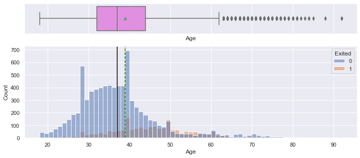

```python
# selecting numerical columns
num_col = custDataAttr.select_dtypes(include=np.number).columns.tolist()

histogram_boxplot(custDataAttr, "Age")
```

**Observations**

- Most customers are between age 25 - 50.
- Long tail indicates outliers.
- **Customers who churn are between the age 45 - 60**

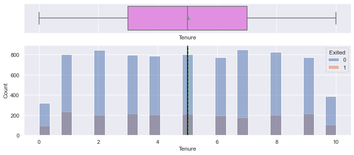

```python
histogram_boxplot(custDataAttr, "Tenure")
```

**Observations**

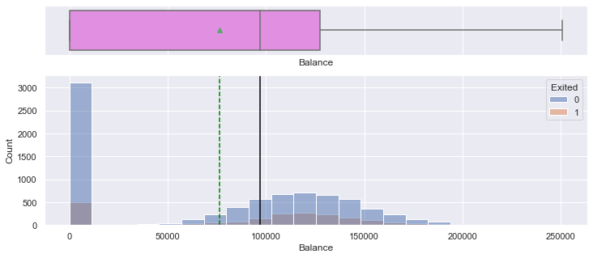

```python
histogram_boxplot(custDataAttr, "Balance")
```

**Observations**

- There are significant customer as zero balance
- Around 17% of the customer who has zero balance churn.

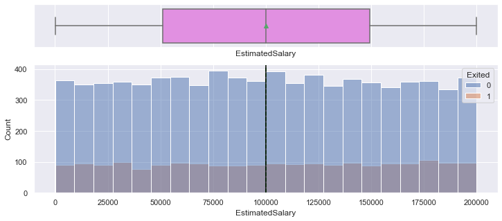

```python
histogram_boxplot(custDataAttr, "EstimatedSalary")
```

##### **Observations**

- Data set has interesting distribution, that roughly 350 customers exist in each salary bin.
- Customers in each bins churn out evenly.

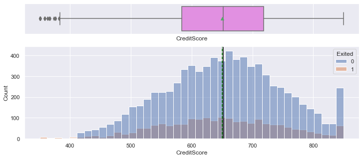

```python
histogram_boxplot(custDataAttr, "CreditScore")
```

```python
# function to create labeled barplots


def labeled_barplot(data, feature, perc=False, n=None):
    """
    Barplot with percentage at the top

    data: dataframe
    feature: dataframe column
    perc: whether to display percentages instead of count (default is False)
    n: displays the top n category levels (default is None, i.e., display all levels)
    """

    total = len(data[feature])  # length of the column
    count = data[feature].nunique()
    if n is None:
        plt.figure(figsize=(count + 1, 5))
    else:
        plt.figure(figsize=(n + 1, 5))

    plt.xticks(rotation=90, fontsize=15)
    ax = sns.countplot(
        data=data,
        x=feature,
        order=data[feature].value_counts().index[:n].sort_values(),
        hue="Exited",
    )

    for p in ax.patches:
        if perc:
            label = "{:.1f}%".format(
                100 * p.get_height() / total
            )  # percentage of each class of the category
        else:
            label = p.get_height()  # count of each level of the category

        x = p.get_x() + p.get_width() / 2  # width of the plot
        y = p.get_height()  # height of the plot

        ax.annotate(
            label,
            (x, y),
            ha="center",
            va="center",
            size=12,
            xytext=(0, 5),
            textcoords="offset points",
        )  # annotate the percentage

    plt.show()  # show the plot
```

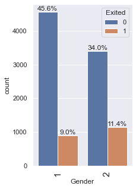

```python
# let's explore Total_visits_bank further
labeled_barplot(custDataAttr, "Gender", perc=True)
```

**Observation**

- **Overall bank has more male customers than female**
- **Female churn more than male**

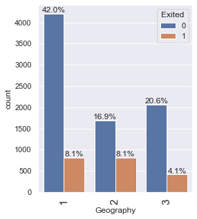

```python
# let's explore Total_visits_bank further
labeled_barplot(custDataAttr, "Geography", perc=True)
```

**Observation**

- **More than half of the customers are French**
- **Germans churn significantly**
- **French and Spain has same churn rate.**

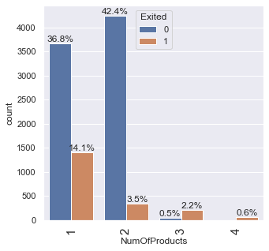

```python
# let's explore Total_visits_bank further
labeled_barplot(custDataAttr, "NumOfProducts", perc=True)
```

**Observation**

- **Customers who purchase more products churn. Needs more attention as this is counter intuitive.**
- **Customers with 2 products stays with the bank**

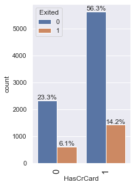

```python
# let's explore Total_visits_bank further
labeled_barplot(custDataAttr, "HasCrCard", perc=True)
```

**Observation**

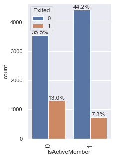

```python
# let's explore Total_visits_bank further
labeled_barplot(custDataAttr, "IsActiveMember", perc=True)
```

**Observation**

- **Non Active members churn**

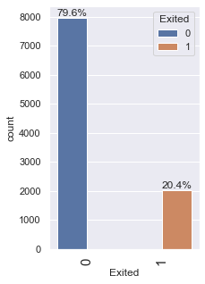

```python
# let's explore Total_visits_bank further
labeled_barplot(custDataAttr, "Exited", perc=True)
```

**Observation**

- **Exited is target variable**
- Data set has more observation on customers who did not leave. **Dataset is imbalanced**

## Bivariate Analysis

Multivariate analysis is performed to understand interactions between different fields in the dataset (or) finding interactions between variables more than 2

### Correlation check

Heatmap is a great way to visualize data, because it can show the relation between variabels in a color-encoded matrix

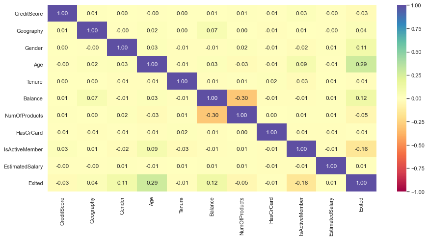

```python
plt.figure(figsize=(15, 7))
sns.heatmap(
    custDataAttr[num_col].corr(),
    annot=True,
    vmin=-1,
    vmax=1,
    fmt=".2f",
    cmap="Spectral",
)
plt.show()
```

**Observations**

- Target variable `Exited` has some **positive co-relation with Age.**
- Also, variable `Exited` has some **negative co-relation with isActiveMember and NumOfProducts.**
- Account balance has negative relationship with number of products that a customer has purchased through the bank.

### Plot pairwise relationships

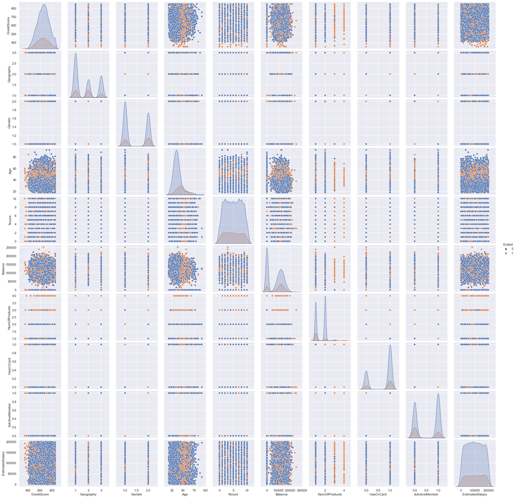

```python
sns.pairplot(data=custDataAttr[num_col], diag_kind="kde", hue="Exited")
plt.show()
```

## Data Preprocessing

During the data preparation stage, raw data is transformed into an easily digestible format for efficient ML algorithms. Then, all features in the data set are normalized to the same scale (unit) for clustering.

### Balance the data set

There are three ways to deal with the imbalanced data set.

- Over sampling,
- Under sampling, and
- Class weights.

Over sampling and under sampling methods give more weight to particular classes by duplicating observations and giving more influence in the model fit. This usually happens in the training data set.

Class weights modifies the loss function by penalizing the classes with weights. This sacrifices ability to predict the lower weight class by biasing the model to favor more accurate predictions of the higher weighted class.

Class weights performs better than sampling techniques, so **model class weights is used to balance the data.**

*Check Appendix for more details.*

### Transform data using column transformer in a pipeline

- A pipeline is created with a processor for certain numerical columns and 2 processor for categorical columns
- Columns that has outliers and significant variations are normalized using standard scaler.
- Categorical columns (Gender and Geography) are encoded using "one hot encoder".
- Data set is transformed using pipeline and used to build the model

```python
scaler = StandardScaler()
# scaler = MinMaxScaler()

pipeline = Pipeline(
    steps=[
        (
            "Categorizer",
            ColumnTransformer(
                [
                    (
                        "Gender one hot encoder",
                        OneHotEncoder(categories="auto", drop="first"),
                        ["Gender"],
                    ),
                    (
                        "Geography one hot encoder",
                        OneHotEncoder(categories="auto", drop="first"),
                        ["Geography"],
                    ),
                ],
                remainder="passthrough",
                n_jobs=1,
            ),
        ),
        ("Normalizer", scaler),
    ]
)
```

### Data Preparation

- Split the data set (70/30 split) for training and testing.
- Stratify the split to evenly distribute and preserve the proportion of target variable (80:20).

```python
custDataScaled = custDataAttr.copy()
X = custDataScaled.drop("Exited", axis=1)
y = custDataScaled.pop("Exited")
```

```python
print(custDataScaled.shape)
```

```
(10000, 10)
```

```python
print(X.shape, y.shape)
```

```
(10000, 10) (10000,)
```

```python
# Splitting data into training, and test set
# Use stratify to maintain the proportionality of the data in test
X_train, X_test, y_train, y_test = train_test_split(
    X, y, test_size=0.30, random_state=1, stratify=y
)
```

```python
print(X_train.shape, X_test.shape)
print(X_test.shape, y_test.shape)
```

```
(7000, 10) (3000, 10)
(3000, 10) (3000,)
```

```python
# Scaling fitted only to training set to avoid information leakage.
X_train = pipeline.fit_transform(X_train)
X_test = pipeline.transform(X_test)
```

### Building Artificial Neural Network.

- ANN has one hidden layer and one output layer.
- For hidden layer,
  - Relu function is used as the activation function because of its ability to learn nonlinear functions.
  - "70% of the number of dimension" is the formula used to choose number of neurons, so **0.7 X 11 =~ 8** is chosen for input. This formula is identified with number of trial and error run.
- For output layer,
  - Sigmoid functions is used as the activation function because this model is used for binary classification.
  - Number of neuron is one.
- Decided not to use "Dropout" regularization as it degraded the model performance.
- For Gradient Descent tuning,
  - `adam` algorithm is used to find optimal weights.
  - `binary_crossentropy` loss function is used with in `adam` algorithm
  - `Accuracy` metric is evaluated as a criteria for model improvement.

*Check Appendix for more details.*

```python
# Initialize the constructor
relumodel = Sequential()

# Define model architecture

# Relu function is used as the activation function.

relumodel.add(Dense(8, activation="relu", name="Hidden_layer"))
# relumodel.add(Dropout(rate=0.1))

relumodel.add(Dense(1, activation="sigmoid", name="Output_layer"))

relumodel.compile(loss="binary_crossentropy", optimizer="adam", metrics=["Accuracy"])
```

#### Class weights

Apply class weight to compensate imbalanced data.

`0 means No ( Customer did not leave the bank which is 80% of dataset ) and 1 means Yes ( Customer left the bank which is 20% of dataset)`

Treat every instance of class 1 as 4 instances of class 0. This means that loss function assign higher value to these instances. Hence, the loss becomes a weighted average, where the weight of each sample is specified by class_weight and its corresponding class.

In bank dataset, class 0 is 80% and class 1 is 20%

So class 0 weight is 1 and class 1 weight is 4 (80/20)

```python
class_weight = {0: 1.0, 1: 4}
```

#### Early stopping

Early stopping is used to stop training when a monitored metric has stopped improving.

```python
# Early stopping
earlystop = keras.callbacks.EarlyStopping(
    monitor="val_loss",
    min_delta=0,
    patience=15,
    verbose=0,
    mode="min",
    restore_best_weights=True,
)
```

#### Train the model

- 50 samples are passed per gradient update.
- 100 iteration is executed to tune the weights.
- 20% of the training data to be used as validation data
- Previously constructed `early stopping` is passed as callback to apply.
- Class weight is passed to pay attention to under represented data.

```python
relumodel.fit(
    X_train,
    y_train,
    validation_split=0.2,
    epochs=100,
    batch_size=50,
    verbose=1,
    callbacks=[earlystop],
    class_weight=class_weight,
)
```

```
<keras.callbacks.History at 0x7f99544ad670>
```

```python
relumodel.summary()
```

```
Model: "sequential"
_________________________________________________________________
Layer (type)                 Output Shape              Param #
=================================================================
Hidden_layer (Dense)         (50, 8)                   96
_________________________________________________________________
Output_layer (Dense)         (50, 1)                   9
=================================================================
Total params: 105
Trainable params: 105
Non-trainable params: 0
_________________________________________________________________
```

### Model evaluation criterion

#### What does a bank want?

- A bank wants to minimize the churn too increase profitability.

#### Model can make wrong predictions as:

- Predicting a customer will churn but stays with the bank.
- Predicting a customer will not churn and the customer leaves the bank.

#### Which case is more important? Which loss is greater?

- Predicting a customer will not churn but actually leaves the bank.

#### How to reduce this loss i.e need to reduce False Negatives?

- Bank would want `Recall` to be maximized, greater the Recall higher the chances of minimizing false negatives. Hence, the focus should be on increasing Recall or minimizing the false negatives.

#### Utility function to graphically display Confusion Matrix

```python
def make_confusion_matrix(model, test_X, y_actual, labels=[1, 0]):
    """
    model : classifier to predict values of X
    test_X: test set
    y_actual : ground truth

    """
    y_predict = model.predict(test_X)
    # Convert Predicted probabilities into binary outcome
    y_predict = (y_predict >= 0.5).astype(int)

    cm = metrics.confusion_matrix(y_actual, y_predict, labels=[0, 1])
    df_cm = pd.DataFrame(
        cm,
        index=[i for i in ["Actual - No", "Actual - Yes"]],
        columns=[i for i in ["Predicted - No", "Predicted - Yes"]],
    )
    group_counts = ["{0:0.0f}".format(value) for value in cm.flatten()]
    group_percentages = ["{0:.2%}".format(value) for value in cm.flatten() / np.sum(cm)]
    labels = [f"{v1}\n{v2}" for v1, v2 in zip(group_counts, group_percentages)]
    labels = np.asarray(labels).reshape(2, 2)
    plt.figure(figsize=(10, 7))
    sns.heatmap(df_cm, annot=labels, fmt="")
    plt.ylabel("True label")
    plt.xlabel("Predicted label")
```

#### Utility function to get model metrics

```python
def get_metrics_score(
    model, train, test, train_y, test_y, threshold=0.5, flag=True, roc=False
):
    """
    Function to calculate different metric scores of the model - Accuracy, Recall, Precision, and F1 score
    model: classifier to predict values of X
    train, test: Independent features
    train_y,test_y: Dependent variable
    threshold: thresold for classifiying the observation as 1
    flag: If the flag is set to True then only the print statements showing different will be displayed. The default value is set to True.
    roc: If the roc is set to True then only roc score will be displayed. The default value is set to False.
    """
    # defining an empty list to store train and test results

    score_list = []

    pred_train = model.predict(train).ravel() > threshold
    pred_test = model.predict(test).ravel() > threshold

    pred_train = np.round(pred_train)
    pred_test = np.round(pred_test)

    train_acc = accuracy_score(pred_train, train_y)
    test_acc = accuracy_score(pred_test, test_y)

    train_recall = recall_score(train_y, pred_train)
    test_recall = recall_score(test_y, pred_test)

    train_precision = precision_score(train_y, pred_train)
    test_precision = precision_score(test_y, pred_test)

    train_f1 = f1_score(train_y, pred_train)
    test_f1 = f1_score(test_y, pred_test)

    train_roc_auc = roc_auc_score(train_y, pred_train)
    test_roc_auc = roc_auc_score(test_y, pred_test)

    score_list.extend(
        (
            train_acc,
            test_acc,
            train_recall,
            test_recall,
            train_precision,
            test_precision,
            train_f1,
            test_f1,
        )
    )

    if flag == True:
        print("Accuracy on training set : ", accuracy_score(pred_train, train_y))
        print("Accuracy on test set : ", accuracy_score(pred_test, test_y))
        print("Recall on training set : ", recall_score(train_y, pred_train))
        print("Recall on test set : ", recall_score(test_y, pred_test))
        print("Precision on training set : ", precision_score(train_y, pred_train))
        print("Precision on test set : ", precision_score(test_y, pred_test))
        print("F1 on training set : ", f1_score(train_y, pred_train))
        print("F1 on test set : ", f1_score(test_y, pred_test))

    if roc == True:
        print("ROC-AUC Score on training set : ", roc_auc_score(train_y, pred_train))
        print("ROC-AUC Score on test set : ", roc_auc_score(test_y, pred_test))

        # creating a dataframe of metrics
    df_perf = pd.DataFrame(
        {
            "Train Accuracy": train_acc,
            "Test Accuracy": test_acc,
            "Train Recall": train_recall,
            "Test Recall": test_recall,
            "Train Precision": train_precision,
            "Test Precision": test_precision,
            "Train F1": train_f1,
            "Test F1": test_f1,
            "Train ROC-AUC": train_roc_auc,
            "Test ROC-AUC": test_roc_auc,
        },
        index=[0],
    )
    return df_perf  # returning the list with train and test scores
```

### Evaluate Neural Network performance using confusion matrix

```
Accuracy on training set :  0.7948571428571428
Accuracy on test set :  0.7876666666666666
Recall on training set :  0.7601683029453016
Recall on test set :  0.7397708674304418
Precision on training set :  0.49770431588613406
Precision on test set :  0.4860215053763441
F1 on training set :  0.6015538290788013
F1 on test set :  0.5866320571057755
ROC-AUC Score on training set :  0.7819499569983055
ROC-AUC Score on test set :  0.7698435751970124
```

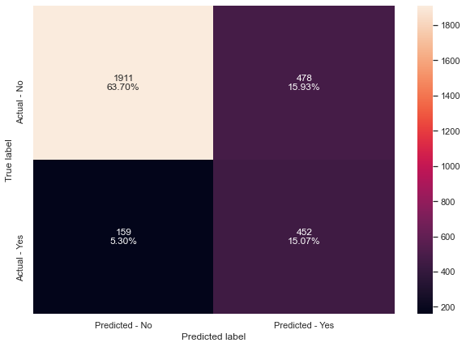

```python
# creating confusion matrix
make_confusion_matrix(relumodel, X_test, y_test)

# checking model performance
scores_relu = get_metrics_score(
    relumodel, X_train, X_test, y_train, y_test, flag=True, roc=True
)
```

`0 means No ( Customer did not leave the bank which is 80% of dataset ) and 1 means Yes ( Customer left the bank which is 20% of dataset)

### Performance measurement using ROC-AUC

The Area Under the Curve (AUC) is the measure of the ability of a classifier model to distinguish between classes and is used as a summary of the ROC curve.

*Check Appendix for more details.*

##### ROC-AUC on training set

```
Training set optimal threshold:  0.52638614
```

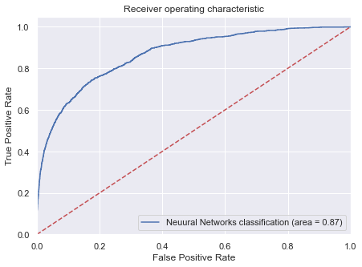

```python
nn_roc_auc_train = roc_auc_score(y_train, relumodel.predict(X_train).ravel())
fpr, tpr, thresholds = roc_curve(y_train, relumodel.predict(X_train).ravel())
optimal_idx = np.argmax(tpr - fpr)
optimal_threshold_auc_roc = thresholds[optimal_idx]
print("Training set optimal threshold: ", optimal_threshold_auc_roc)

plt.figure(figsize=(7, 5))
plt.plot(
    fpr, tpr, label="Neuural Networks classification (area = %0.2f)" % nn_roc_auc_train
)
plt.plot([0, 1], [0, 1], "r--")
plt.xlim([0.0, 1.0])
plt.ylim([0.0, 1.05])
plt.xlabel("False Positive Rate")
plt.ylabel("True Positive Rate")
plt.title("Receiver operating characteristic")
plt.legend(loc="lower right")
plt.show()
```

##### ROC-AUC on test set

```
Testing set optimal threshold:  0.4647754
```

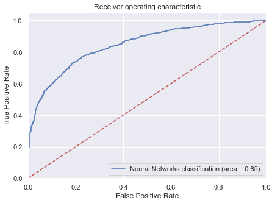

```python
nn_roc_auc_test = roc_auc_score(y_test, relumodel.predict(X_test).ravel())
fpr, tpr, thresholds = roc_curve(y_test, relumodel.predict(X_test).ravel())
optimal_idx = np.argmax(tpr - fpr)
optimal_threshold_auc_roc = thresholds[optimal_idx]
print("Testing set optimal threshold: ", optimal_threshold_auc_roc)

plt.figure(figsize=(7, 5))
plt.plot(
    fpr, tpr, label="Neural Networks classification (area = %0.2f)" % nn_roc_auc_test
)
plt.plot([0, 1], [0, 1], "r--")
plt.xlim([0.0, 1.0])
plt.ylim([0.0, 1.05])
plt.xlabel("False Positive Rate")
plt.ylabel("True Positive Rate")
plt.title("Receiver operating characteristic")
plt.legend(loc="lower right")
plt.show()
```

## Model Performance Improvement

- By changing the model threshold, let's evaluate if the recall, precision, F1 and ROC-AUC score can be improved further.

### Optimal threshold using AUC-ROC curve

```python
# Optimal threshold as per AUC-ROC curve
# The optimal cut off would be where tpr is high and fpr is low
fpr, tpr, thresholds = metrics.roc_curve(y_test, relumodel.predict(X_test).ravel())
optimal_idx = np.argmax(tpr - fpr)
optimal_threshold_auc_roc = thresholds[optimal_idx]
print("Testing set optimal threshold: ", optimal_threshold_auc_roc)
```

```
Testing set optimal threshold:  0.4647754
```

```python
scores_AUC_ROC = get_metrics_score(
    relumodel,
    X_train,
    X_test,
    y_train,
    y_test,
    threshold=optimal_threshold_auc_roc,
    roc=True,
)
```

```
Accuracy on training set :  0.7734285714285715
Accuracy on test set :  0.773
Recall on training set :  0.7819074333800842
Recall on test set :  0.7692307692307693
Precision on training set :  0.4665271966527197
Precision on test set :  0.46534653465346537
F1 on training set :  0.5843815513626835
F1 on test set :  0.5798889574336829
ROC-AUC Score on training set :  0.7765834260549506
ROC-AUC Score on test set :  0.7715973854525551
```

- AUC-ROC curve identified 0.465 as optimal threshold for the test data and with this setting
  - Test accuracy has dropped few points from original model, which means lesser overall prediction.
  - Recall has performed very well and improved significantly, which means less incorrect predictions that customers stay in the bank.
  - Notably, Precision has dropped, which means more incorrect predictions that customers leave in the bank.
- As we will decrease the threshold value, Recall will keep on increasing but the Precision will decrease, but that's not right because it will lead to loss of resources, we need to choose an optimal balance between recall and precision.

### Evaluate Precision-Recall curve to find a better threshold

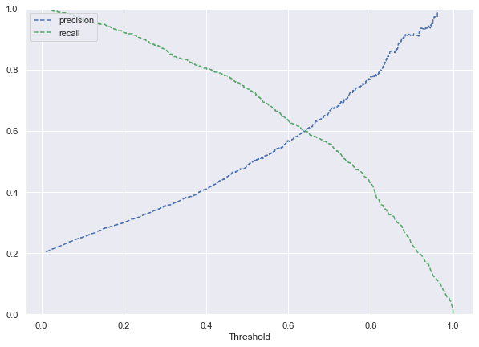

```python
y_scores = relumodel.predict(X_test).ravel()
prec, rec, tre = precision_recall_curve(
    y_test,
    y_scores,
)


def plot_prec_recall_vs_tresh(precisions, recalls, thresholds):
    plt.plot(thresholds, precisions[:-1], "b--", label="precision")
    plt.plot(thresholds, recalls[:-1], "g--", label="recall")
    plt.xlabel("Threshold")
    plt.legend(loc="upper left")
    plt.ylim([0, 1])


plt.figure(figsize=(10, 7))
plot_prec_recall_vs_tresh(prec, rec, tre)
plt.show()
```

```python
optimal_threshold_curve = 0.65

scores_P_R = get_metrics_score(
    relumodel,
    X_train,
    X_test,
    y_train,
    y_test,
    threshold=optimal_threshold_curve,
    roc=True,
)
```

```
Accuracy on training set :  0.8467142857142858
Accuracy on test set :  0.8403333333333334
Recall on training set :  0.6325385694249649
Recall on test set :  0.5924713584288053
Precision on training set :  0.6216402481047554
Precision on test set :  0.6114864864864865
F1 on training set :  0.6270420576989919
F1 on test set :  0.6018287614297589
ROC-AUC Score on training set :  0.767022783097843
ROC-AUC Score on test set :  0.7480983832746789
```

- Precision-Recall curve identified 0.65 as optimal threshold and with this setting
  - Test accuracy has increased few points from original model.
    - Which means better overall prediction when compared to original model.
  - Recall and Precision has balanced at ~60% which means balanced `incorrect predictions that customers stay in the bank.` and `incorrect predictions that customers leave the bank.`

### Metrics score comparison

```python
# performance comparison
models_comp_df = pd.concat(
    [
        scores_relu.T,
        scores_AUC_ROC.T,
        scores_P_R.T,
    ],
    axis=1,
)
models_comp_df.columns = [
    "Neural Networks with Relu",
    "0.465 threshold from ROC-AUC curve with NN Relu",
    "0.65 threshold from Precision-Recall curve with NN Relu",
]
print("Performance comparison:")
models_comp_df.T.sort_values(by=["Test Recall", "Test Accuracy"], ascending=False)
```

```
Performance comparison:
```

|  | Train Accuracy | Test Accuracy | Train Recall | Test Recall | Train Precision | Test Precision | Train F1 | Test F1 | Train ROC-AUC | Test ROC-AUC |
| --- | --- | --- | --- | --- | --- | --- | --- | --- | --- | --- |
| 0.465 threshold from ROC-AUC curve with NN Relu | 0.773429 | 0.773000 | 0.781907 | 0.769231 | 0.466527 | 0.465347 | 0.584382 | 0.579889 | 0.776583 | 0.771597 |
| Neural Networks with Relu | 0.794857 | 0.787667 | 0.760168 | 0.739771 | 0.497704 | 0.486022 | 0.601554 | 0.586632 | 0.781950 | 0.769844 |
| 0.65 threshold from Precision-Recall curve with NN Relu | 0.846714 | 0.840333 | 0.632539 | 0.592471 | 0.621640 | 0.611486 | 0.627042 | 0.601829 | 0.767023 | 0.748098 |

## Appendix - Additional analysis

### Build and evaluate a model based on LeakyRelu Neural Networks

```python
# Initialize the constructor
leakymodel = Sequential()

# Define model architecture
leakymodel.add(Dense(8, activation="LeakyReLU", name="Hidden_layer_1"))
# relumodel.add(Dropout(rate=0.05))
# leakymodel.add(Dense(3, activation="elu", name="Hidden_layer_2"))
leakymodel.add(Dense(1, activation="sigmoid"))
leakymodel.compile(loss="binary_crossentropy", optimizer="adam", metrics=["accuracy"])
```

```python
leakymodel.fit(
    X_train,
    y_train,
    validation_split=0.2,
    epochs=100,
    batch_size=50,
    verbose=1,
    callbacks=[earlystop],
    class_weight=class_weight,
)
```

```
<keras.callbacks.History at 0x7f9957175820>
```

```
Accuracy on training set :  0.7851428571428571
Accuracy on test set :  0.776
Recall on training set :  0.7664796633941094
Recall on test set :  0.734860883797054
Precision on training set :  0.482773851590106
Precision on test set :  0.4681960375391032
F1 on training set :  0.5924119241192413
F1 on test set :  0.5719745222929936
ROC-AUC Score on training set :  0.7781985686902373
ROC-AUC Score on test set :  0.7606912204669657
```

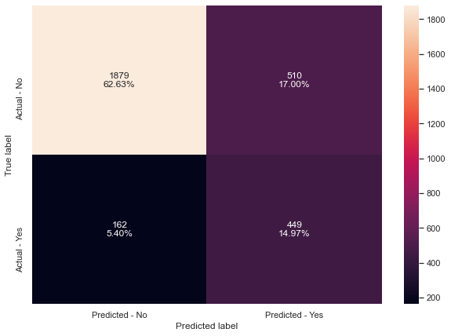

```python
# creating confusion matrix
make_confusion_matrix(leakymodel, X_test, y_test)

# checking model performance
scores_lrelu = get_metrics_score(
    leakymodel, X_train, X_test, y_train, y_test, flag=True, roc=True
)
```

#### AUC-ROC curve

```python
# Optimal threshold as per AUC-ROC curve
# The optimal cut off would be where tpr is high and fpr is low
fpr, tpr, thresholds = metrics.roc_curve(y_test, leakymodel.predict(X_test).ravel())
optimal_idx = np.argmax(tpr - fpr)
optimal_threshold_auc_roc = thresholds[optimal_idx]
print("Testing set optimal threshold: ", optimal_threshold_auc_roc)

lscores_AUC_ROC = get_metrics_score(
    leakymodel,
    X_train,
    X_test,
    y_train,
    y_test,
    threshold=optimal_threshold_auc_roc,
    roc=True,
)
```

```
Testing set optimal threshold:  0.50146186
Accuracy on training set :  0.7855714285714286
Accuracy on test set :  0.7766666666666666
Recall on training set :  0.7657784011220197
Recall on test set :  0.7332242225859247
Precision on training set :  0.48339973439575035
Precision on test set :  0.46910994764397906
F1 on training set :  0.5926729986431479
F1 on test set :  0.5721583652618135
ROC-AUC Score on training set :  0.7782067463091261
ROC-AUC Score on test set :  0.7605007676345278
```

### Build and evaluate a model based on Tanh Neural Networks

```python
# Initialize the constructor
tanhmodelC = Sequential()

# Define model architecture
tanhmodelC.add(Dense(8, activation="tanh", name="Hidden_layer_1"))
# relumodel.add(Dropout(rate=0.05))
# leakymodel.add(Dense(3, activation="elu", name="Hidden_layer_2"))
tanhmodelC.add(Dense(1, activation="sigmoid"))
tanhmodelC.compile(loss="binary_crossentropy", optimizer="adam", metrics=["accuracy"])
```

```python
tanhmodelC.fit(
    X_train,
    y_train,
    validation_split=0.2,
    epochs=100,
    batch_size=50,
    verbose=1,
    callbacks=[earlystop],
    class_weight=class_weight,
)
```

```
<keras.callbacks.History at 0x7f9958293700>
```

```
Accuracy on training set :  0.7911428571428571
Accuracy on test set :  0.7816666666666666
Recall on training set :  0.7791023842917251
Recall on test set :  0.7463175122749591
Precision on training set :  0.4920283436669619
Precision on test set :  0.4769874476987448
F1 on training set :  0.6031487513572203
F1 on test set :  0.5820038289725591
ROC-AUC Score on training set :  0.7866627816686469
ROC-AUC Score on test set :  0.7685124606163409
```

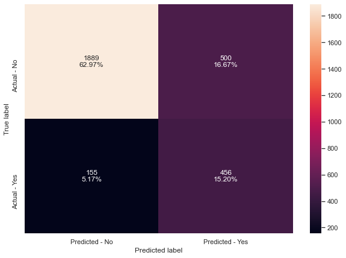

```python
# creating confusion matrix
make_confusion_matrix(tanhmodelC, X_test, y_test)

# checking model performance
scores_tanhC = get_metrics_score(
    tanhmodelC, X_train, X_test, y_train, y_test, flag=True, roc=True
)
```

### Build and evaluate a model based on Tanh Neural Network and SMOTE

#### SMOTE to upsample smaller class

```python
# To be used for over sampling
from imblearn.over_sampling import SMOTE

print("Before UpSampling, counts of label '1': {}".format(sum(y_train == 1)))
print("Before UpSampling, counts of label '0': {} \n".format(sum(y_train == 0)))

sm = SMOTE(
    sampling_strategy=1, k_neighbors=5, random_state=1
)  # Synthetic Minority Over Sampling Technique
X_train_res, y_train_res = sm.fit_resample(X_train, y_train.ravel())


print("After UpSampling, counts of label '1': {}".format(sum(y_train_res == 1)))
print("After UpSampling, counts of label '0': {} \n".format(sum(y_train_res == 0)))


print("After UpSampling, the shape of train_X: {}".format(X_train_res.shape))
print("After UpSampling, the shape of train_y: {} \n".format(y_train_res.shape))
```

```
Before UpSampling, counts of label '1': 1426
Before UpSampling, counts of label '0': 5574

After UpSampling, counts of label '1': 5574
After UpSampling, counts of label '0': 5574

After UpSampling, the shape of train_X: (11148, 11)
After UpSampling, the shape of train_y: (11148,)
```

```python
# Initialize the constructor
tanhmodel = Sequential()

# Define model architecture
tanhmodel.add(Dense(8, activation="tanh", name="Hidden_layer_1"))
# relumodel.add(Dropout(rate=0.05))
# leakymodel.add(Dense(3, activation="elu", name="Hidden_layer_2"))
tanhmodel.add(Dense(1, activation="sigmoid"))
tanhmodel.compile(loss="binary_crossentropy", optimizer="adam", metrics=["accuracy"])
```

```python
tanhmodel.fit(
    X_train_res,
    y_train_res,
    validation_split=0.2,
    epochs=100,
    batch_size=50,
    verbose=1,
    callbacks=[earlystop],
)
```

```
<keras.callbacks.History at 0x7f9954f14a60>
```

```
Accuracy on training set :  0.7955687118765697
Accuracy on test set :  0.8343333333333334
Recall on training set :  0.7100825260136348
Recall on test set :  0.6579378068739771
Precision on training set :  0.8565245617831638
Precision on test set :  0.5826086956521739
F1 on training set :  0.7764590485532123
F1 on test set :  0.6179861644888547
ROC-AUC Score on training set :  0.7955687118765697
ROC-AUC Score on test set :  0.7686926372168128
```

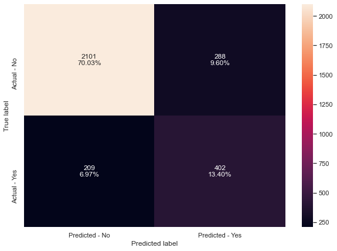

```python
# creating confusion matrix
make_confusion_matrix(tanhmodel, X_test, y_test)

# checking model performance
scores_tanh = get_metrics_score(
    tanhmodel, X_train_res, X_test, y_train_res, y_test, flag=True, roc=True
)
```

### Build and evaluate a model based on DecisionTreeClassifier

```
Accuracy on training set :  1.0
Accuracy on test set :  0.7873333333333333
Recall on training set :  1.0
Recall on test set :  0.4762684124386252
Precision on training set :  1.0
Precision on test set :  0.47783251231527096
F1 on training set :  1.0
F1 on test set :  0.47704918032786886
ROC-AUC Score on training set :  1.0
ROC-AUC Score on test set :  0.6715791622678685
```

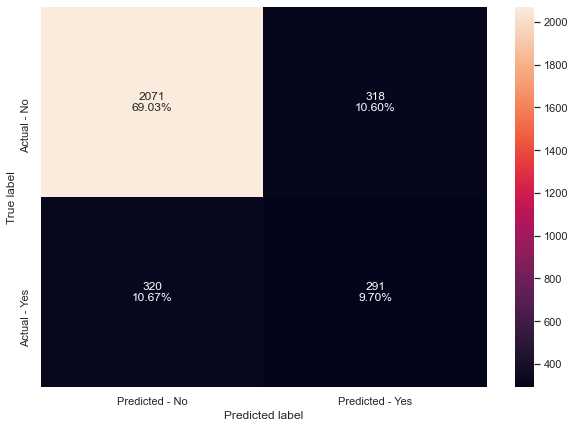

```python
decisiontree = tree.DecisionTreeClassifier(class_weight=class_weight)
decisiontree.fit(X_train, y_train)

# creating confusion matrix
make_confusion_matrix(decisiontree, X_test, y_test)

# checking model performance
scores_DT = get_metrics_score(
    decisiontree, X_train, X_test, y_train, y_test, flag=True, roc=True
)
```

### Build and evaluate a model based on RandomForestClassifier

```
Accuracy on training set :  1.0
Accuracy on test set :  0.8606666666666667
Recall on training set :  1.0
Recall on test set :  0.43044189852700493
Precision on training set :  1.0
Precision on test set :  0.7897897897897898
F1 on training set :  1.0
F1 on test set :  0.5572033898305084
ROC-AUC Score on training set :  1.0
ROC-AUC Score on test set :  0.700570467890543
```

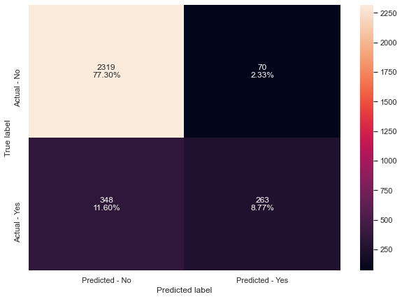

```python
randomclassifier = RandomForestClassifier(
    n_estimators=200, random_state=200, class_weight=class_weight
)
randomclassifier.fit(X_train, y_train)

# creating confusion matrix
make_confusion_matrix(randomclassifier, X_test, y_test)

# checking model performance
scores_RF = get_metrics_score(
    randomclassifier, X_train, X_test, y_train, y_test, flag=True, roc=True
)
```

### Build and evaluate a model based on XGBClassifier

```
Accuracy on training set :  0.9998571428571429
Accuracy on test set :  0.8376666666666667
Recall on training set :  1.0
Recall on test set :  0.5400981996726678
Precision on training set :  0.9992992291520673
Precision on test set :  0.6156716417910447
F1 on training set :  0.9996494917630564
F1 on test set :  0.5754141238012206
ROC-AUC Score on training set :  0.9999102978112666
ROC-AUC Score on test set :  0.7269348260816247
```

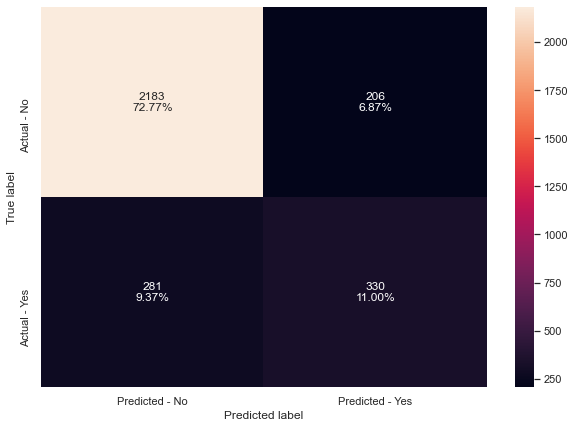

```python
xgbclassifier = XGBClassifier(
    max_depth=12,
    random_state=7,
    n_estimators=100,
    eval_metric="auc",
    min_child_weight=3,
    colsample_bytree=0.75,
    subsample=0.8,
    scale_pos_weight=4,
)
xgbclassifier.fit(X_train, y_train)

# creating confusion matrix
make_confusion_matrix(xgbclassifier, X_test, y_test)

# checking model performance
scores_XGB = get_metrics_score(
    xgbclassifier, X_train, X_test, y_train, y_test, flag=True, roc=True
)
```

### All model performance comparison

```python
# training performance comparison
models_comp_df = pd.concat(
    [
        scores_relu.T,
        scores_AUC_ROC.T,
        scores_P_R.T,
        scores_lrelu.T,
        lscores_AUC_ROC.T,
        scores_tanh.T,
        scores_tanhC.T,
        scores_DT.T,
        scores_RF.T,
        scores_XGB.T,
    ],
    axis=1,
)
models_comp_df.columns = [
    "Neural Networks with Relu",
    "0.465 threshold from AUC-ROC curve with NN Relu",
    "0.65 threshold from Precision-Recall curve with NN Relu",
    "Neural Networks with leaky Relu",
    "0.5 threshold from AUC-ROC curve with NN Leaky Relu",
    "Neural Networks with Tanh/SMOTE",
    "Neural Networks with Tanh/Class_Weight",
    "Decision tree",
    "Random forest",
    "XGradient Boost",
]
print("Performance comparison:")
models_comp_df.T.sort_values(by=["Test Recall", "Test Accuracy"], ascending=False)
```

```
Performance comparison:
```

|  | Train Accuracy | Test Accuracy | Train Recall | Test Recall | Train Precision | Test Precision | Train F1 | Test F1 | Train ROC-AUC | Test ROC-AUC |
| --- | --- | --- | --- | --- | --- | --- | --- | --- | --- | --- |
| 0.465 threshold from AUC-ROC curve with NN Relu | 0.773429 | 0.773000 | 0.781907 | 0.769231 | 0.466527 | 0.465347 | 0.584382 | 0.579889 | 0.776583 | 0.771597 |
| Neural Networks with Tanh/Class_Weight | 0.791143 | 0.781667 | 0.779102 | 0.746318 | 0.492028 | 0.476987 | 0.603149 | 0.582004 | 0.786663 | 0.768512 |
| Neural Networks with Relu | 0.794857 | 0.787667 | 0.760168 | 0.739771 | 0.497704 | 0.486022 | 0.601554 | 0.586632 | 0.781950 | 0.769844 |
| Neural Networks with leaky Relu | 0.785143 | 0.776000 | 0.766480 | 0.734861 | 0.482774 | 0.468196 | 0.592412 | 0.571975 | 0.778199 | 0.760691 |
| 0.5 threshold from AUC-ROC curve with NN Leaky Relu | 0.785571 | 0.776667 | 0.765778 | 0.733224 | 0.483400 | 0.469110 | 0.592673 | 0.572158 | 0.778207 | 0.760501 |
| Neural Networks with Tanh/SMOTE | 0.795569 | 0.834333 | 0.710083 | 0.657938 | 0.856525 | 0.582609 | 0.776459 | 0.617986 | 0.795569 | 0.768693 |
| 0.65 threshold from Precision-Recall curve with NN Relu | 0.846714 | 0.840333 | 0.632539 | 0.592471 | 0.621640 | 0.611486 | 0.627042 | 0.601829 | 0.767023 | 0.748098 |
| XGradient Boost | 0.999857 | 0.837667 | 1.000000 | 0.540098 | 0.999299 | 0.615672 | 0.999649 | 0.575414 | 0.999910 | 0.726935 |
| Decision tree | 1.000000 | 0.787333 | 1.000000 | 0.476268 | 1.000000 | 0.477833 | 1.000000 | 0.477049 | 1.000000 | 0.671579 |
| Random forest | 1.000000 | 0.860667 | 1.000000 | 0.430442 | 1.000000 | 0.789790 | 1.000000 | 0.557203 | 1.000000 | 0.700570 |

### Feature Importance

```python
custDataScaled1 = custDataAttr.copy()
X1 = custDataScaled1.drop("Exited", axis=1)
y1 = custDataScaled1.pop("Exited")

X1 = pd.get_dummies(X1, columns=["Gender", "Geography"], drop_first=True)

# Splitting data in train and test sets
X_train1, X_test1, y_train1, y_test1 = train_test_split(
    X1, y1, test_size=0.30, random_state=1, stratify=y
)
```

```python
feature_names = list(X_train1.columns)
print(feature_names)
```

```
['CreditScore', 'Age', 'Tenure', 'Balance', 'NumOfProducts', 'HasCrCard', 'IsActiveMember', 'EstimatedSalary', 'Gender_2', 'Geography_2', 'Geography_3']
```

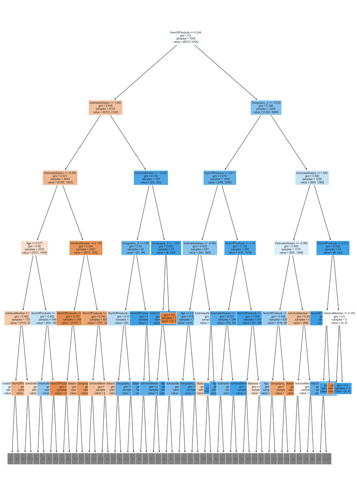

```python
plt.figure(figsize=(20, 30))
out = tree.plot_tree(
    decisiontree,
    feature_names=feature_names,
    filled=True,
    fontsize=9,
    node_ids=False,
    class_names=None,
    max_depth=5,
)
# below code will add arrows to the decision tree split if they are missing
for o in out:
    arrow = o.arrow_patch
    if arrow is not None:
        arrow.set_edgecolor("black")
        arrow.set_linewidth(1)
plt.show()
```

```python
# importance of features in the tree building ( The importance of a feature is computed as the
# (normalized) total reduction of the criterion brought by that feature. It is also known as the Gini importance )

print(
    pd.DataFrame(
        decisiontree.feature_importances_, columns=["Imp"], index=X_train1.columns
    ).sort_values(by="Imp", ascending=False)
)
```

```
                      Imp
NumOfProducts    0.264144
IsActiveMember   0.159777
EstimatedSalary  0.144064
Balance          0.134276
Geography_3      0.123794
HasCrCard        0.065532
Geography_2      0.037000
Age              0.023163
CreditScore      0.022411
Gender_2         0.014560
Tenure           0.011280
```

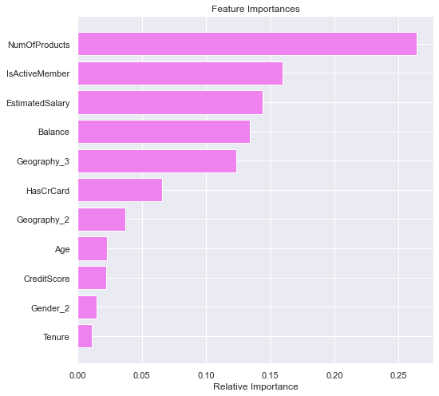

```python
importances = decisiontree.feature_importances_
indices = np.argsort(importances)

plt.figure(figsize=(8, 8))
plt.title("Feature Importances")
plt.barh(range(len(indices)), importances[indices], color="violet", align="center")
plt.yticks(range(len(indices)), [feature_names[i] for i in indices])
plt.xlabel("Relative Importance")
plt.show()
```